# Examining the Business Cycle from 1947 to the Present

Mel Maniwan

20 January, 2021

# About the Project

I want to investigate the basic features of the modern US Economy in order to better understand the underlying principles and lessons articulated in Robert T. McGee’s book - Applied Financial Macroeconomics & Investment Strategy - A Practitioner’s Guide to Tactical Asset Allocation, wherein the author’s aim is to give readers a better understanding of the business cycle by cutting through noise generated by talking-heads and day to day (and even month to month) fluctuations of various indicators to find meaningful signals relating to economic trends. My rationale is that by actively replicating and applying econometric and other data analysis methods on indicators talked about by the author, as well as taking in additional peer reviewed articles along with data, it can lead to personal development skill development and

in myself an (albeit relative to economists and practitioners- superficial) understanding of the Business Cycle. I begin by briefly examining the modern US Economy by looking at key indicators that help point to changes over time. I begin by looking at the percentage change to Real Gross Domestic Product (GDP) before moving on to indicators used by the Dating Committee of the National Bureau of Economic Research (NBER) - 1. Non-farm payrolls, 2. real personal income less transfer payments from the government, 3. industrial production and 4. real manufacturing trade and sales. I then briefly articulating the the causes, duration and affected sectors of each of the last 12 recessions. This includes the current COVID-19 recession and the focus of Robert T. McGee’s final analysis based on principles discussed in his book- The Great Recession. More about these two recessions shall be discussed in detail later towards the end of this research endeavor.

#### Why does this matter for your longer term interest in understanding the effects of factory shutdowns, ethnolinguistic fractionalization and nativism?

As someone interested in understanding the relationship between how nativist candidates exploit socioeconomic upheavals in areas with low Ethnolinguistic Fractionalization scores; knowing how far off nativist perception is of national economic performance from the actual state of the economy in the cycle is crucial for a variety of reasons, namely, to better gauge how well grounded economic anxiety of interviewed individuals are to reality. Second, to understand expansion and contraction of manufacturing and information technology in the United States as it relates to short and long term market forces at play. The earlier industry has seen an exodus of decent paying jobs overseas despite the increase of overall productivity. The decline in jobs in manufacturing has been used as a talking point in 2016 by nativist presidential candidate - Donald J. Trump. whereas the latter industry faces the opposite but nevertheless serious problem of a skills shortage despite the high pay due to a higher barrier to entry - an education in or an equivalent training in computer science and/or other applied sciences/engineering.

## Timeline of the US Economy

Below, I prepared an interactive time series graph of Real Gross Domestic Product (GDP) of the United States of America from the 2nd quarter of 1947 to the 3rd quarter of 2020 and is measured using a seasonally adjusted annual rate (SAAR) estimate of the percentage change of Real GDP from the preceding quarter. The original data had already been prepared by the United State’s Bureau of Economic Analysis, which is also the source for the data.[1] I chose to plot the percentage change of Real GDP as opposed to other measures of GDP (like nominal GDP or even real GDP) so as to contextualize change to the national economy per quarter.I decided to shade and label periods in the graph where there was a recession as called by the National Bureau of Economic Research (NBER) - the agency responsible for officially making the call when recessions are occurring in the United States.

[interactive chart not shown]

#### Summary of Data on seasonally adjusted annual rate (SAAR) estimate of the percentage change of Real GDP from the preceding quarter

I decide to break down the data by comparing the distribution of the estimate of interest by whether or not there was a recession declared by the NBER for all quarters in the data set. As we can see, there are outliers present in both distributions; although the extreme cases of growth and contraction is seen with the recession group. But as expected, most of the data appear to follow a normal distribution in their respective groupings, although it ought to be noted, that while there are 294 observations from both groups, 242 observed quarters are from the not in a recession group while the remaining 52 observed quarters were in one. Further, the average length of the past 12 recessions (rounding to the nearest whole number) is 4 quarters long, although the most frequent value is 3 quarters long. This does verify the claim of the author that recessions have become much shorter in this modern era.

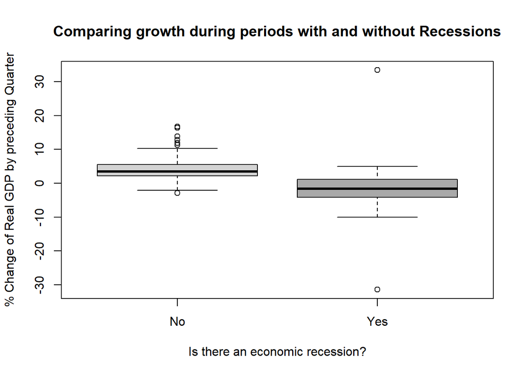

```r
boxplot(data = pc_rgdp, A191RL1Q225SBEA ~ RECESSION,
        names = c("No","Yes"),
        col = c("light grey","dark grey"),
        main = "Comparing growth during periods with and without Recessions",
        xlab = "Is there an economic recession?",
        ylab = "% Change of Real GDP by preceding Quarter")
```

```r
pc_rgdp %>%
  group_by(RECESSION) %>%
  rename("%-change-real-gdp" = "A191RL1Q225SBEA") %>%
  summarise(max = max(`%-change-real-gdp`),
            min = min(`%-change-real-gdp`),
            median = median(`%-change-real-gdp`),
            mean = mean(`%-change-real-gdp`),
            sd = sd(`%-change-real-gdp`))
```

```
## # A tibble: 2 x 6
##   RECESSION   max   min median  mean    sd
##       <int> <dbl> <dbl>  <dbl> <dbl> <dbl>
## 1         0  16.7  -2.9    3.5  4.14  3.19
## 2         1  33.4 -31.4   -1.6 -1.35  7.28
```

```r
pc_rgdp %>%
  group_by(RECESSION) %>%
  tally()
```

```
## # A tibble: 2 x 2
##   RECESSION     n
##       <int> <int>
## 1         0   242
## 2         1    52
```

```r
getmode <- function(v) {
   uniqv <- unique(v)
   uniqv[which.max(tabulate(match(v, uniqv)))]
}

pc_rgdp %>%
  filter(RECESSION == 1) %>%
  group_by(NAME) %>%
  tally() %>%
  summarise(getmode(n))
```

```
## # A tibble: 1 x 1
##   `getmode(n)`
##          <int>
## 1            3
```

```r
pc_rgdp %>%
  filter(RECESSION == 1) %>%
  group_by(NAME) %>%
  rename("%-change-real-gdp" = "A191RL1Q225SBEA") %>%
  summarise(max = max(`%-change-real-gdp`),
            min = min(`%-change-real-gdp`),
            median = median(`%-change-real-gdp`),
            mean = mean(`%-change-real-gdp`),
            sd = sd(`%-change-real-gdp`))
```

```
## # A tibble: 12 x 6
##    NAME                        max   min median   mean    sd
##    <chr>                     <dbl> <dbl>  <dbl>  <dbl> <dbl>
##  1 1980 Recession              1.3  -8   -0.5   -2.4    4.93
##  2 Dot-com Recession           2.4  -1.7  1.1    0.6    2.10
##  3 Energy Crisis Recession     4.9  -6.1 -0.65  -0.833  4.03
##  4 Gulf War Recession          0.3  -3.6 -1.9   -1.73   1.96
##  5 Oil Embargo Recession       3.8  -4.8 -2.45  -1.43   3.28
##  6 Post-Korean War recession   0.4  -5.9 -2.05  -2.4    2.61
##  7 Post-WWII recession         4.2  -5.4 -1.4   -1.1    3.67
##  8 Recession of 1957-1958      4   -10   -0.700 -1.85   6.49
##  9 Recession of 1960-1961      2.7  -5   -0.05  -0.6    3.62
## 10 Recession of 1969-1970      3.7  -4.2 -0.6   -0.48   2.94
## 11 The Covid-19 Recession     33.4 -31.4 -5     -1     32.6
## 12 The Great Recession         2.1  -8.4 -2.2   -2.62   3.56
```

```r
# To estimate the mean of mean of %-change-real-gdp, activate and append code below to above.
# %>% summarise(mean(mean))
# Value should be -1.320556.

# Remove obsolete object
rm(getmode)
```

When we derive the average from each of the 12 periods of recession’s mean percentage change of real GDP from the previous quarter, we see that the average contraction from each period is about -1.32%, however this generalization may be meaningless when we take into account the severity of contractions in each period, such as in the most recent case, where estimates show a -31.4% decline in the second quarter but only to be swung up to 33.4% in growth during the third quarter of 2020. Therefore it’s best to examine each recession to determine factors that led to these economic downturns. But prior to this endeavor it’s best to examine key economic indicators used by the NBER’s Dating Committee for recession dating. These are 1. non-farm payrolls, 2. real personal income less transfer payments from the government, 3. industrial production and 4. real manufacturing trade and sales. While a good rule of thumb is the definition of a recession as two sequential negative quarters of real GDP growth, another way of looking at whether there is a recession involves knowing if there is a prolonged decline in production, jobs, incomes and spending. Of course the four factors more often than not coincide with the definition, hence its prevalent use.

### Appendix

#### Sources

[1] U.S. Bureau of Economic Analysis, Real Gross Domestic Product [A191RL1Q225SBEA], retrieved from FRED, Federal Reserve Bank of St. Louis; https://fred.stlouisfed.org/series/A191RL1Q225SBEA, January 19, 2021.